# Notebook #3

Simon Garnier

November 25, 2017

# 1 Data

```r
# load required libraries
if (!require(pacman)) install.packages("pacman")
p_load(readr, dplyr, broom, ggplot2, cowplot, sjPlot, lme4)

# load data
num2 <- read_csv("../../data/num2.csv")
num2
```

```
## # A tibble: 80 x 5
##    Length Hardness   Day ColonyID Numbercleared
##     <chr>    <chr> <int>    <int>         <int>
##  1      L        H     2        1             0
##  2      L        H     2        5             2
##  3      L        H     2        9             0
##  4      L        H     2       13            19
##  5      L        H     2       17            31
##  6      L        H     2        4             0
##  7      L        H     2        8            24
##  8      L        H     2       12             1
##  9      L        H     2       16            12
## 10      L        H     2       20             0
## # ... with 70 more rows
```

```r
prop2 <- read_csv("../../data/prop2.csv")
prop2
```

```
## # A tibble: 80 x 5
##    Length Hardness   Day ColonyID Propcleared
##     <chr>    <chr> <int>    <int>       <dbl>
##  1      L        H     2        1 0.000000000
##  2      L        H     2        5 0.006666667
##  3      L        H     2        9 0.000000000
##  4      L        H     2       13 0.063333333
##  5      L        H     2       17 0.103333333
##  6      L        H     2        4 0.000000000
##  7      L        H     2        8 0.080000000
##  8      L        H     2       12 0.003333333
##  9      L        H     2       16 0.040000000
## 10      L        H     2       20 0.000000000
## # ... with 70 more rows
```

```r
num4 <- read_csv("../../data/num4.csv")
num4
```

```
## # A tibble: 80 x 5
##    Length Hardness   Day ColonyID Numbercleared
##     <chr>    <chr> <int>    <int>         <int>
##  1      L        H     4        1             1
##  2      L        H     4        5             8
##  3      L        H     4        9             0
##  4      L        H     4       13           297
##  5      L        H     4       17            79
##  6      L        H     4        4             5
##  7      L        H     4        8            51
##  8      L        H     4       12            24
##  9      L        H     4       16           188
## 10      L        H     4       20             0
## # ... with 70 more rows
```

```r
prop4 <- read_csv("../../data/prop4.csv")
prop4
```

```
## # A tibble: 80 x 5
##    Length Hardness   Day ColonyID Propcleared
##     <chr>    <chr> <int>    <int>       <dbl>
##  1      L        H     4        1 0.003333333
##  2      L        H     4        5 0.026666667
##  3      L        H     4        9 0.000000000
##  4      L        H     4       13 0.990000000
##  5      L        H     4       17 0.263333333
##  6      L        H     4        4 0.016666667
##  7      L        H     4        8 0.170000000
##  8      L        H     4       12 0.080000000
##  9      L        H     4       16 0.626666667
## 10      L        H     4       20 0.000000000
## # ... with 70 more rows
```

Back to top

# 2 Day 2

## 2.1 Number of blades cleared

### 2.1.1 Graph

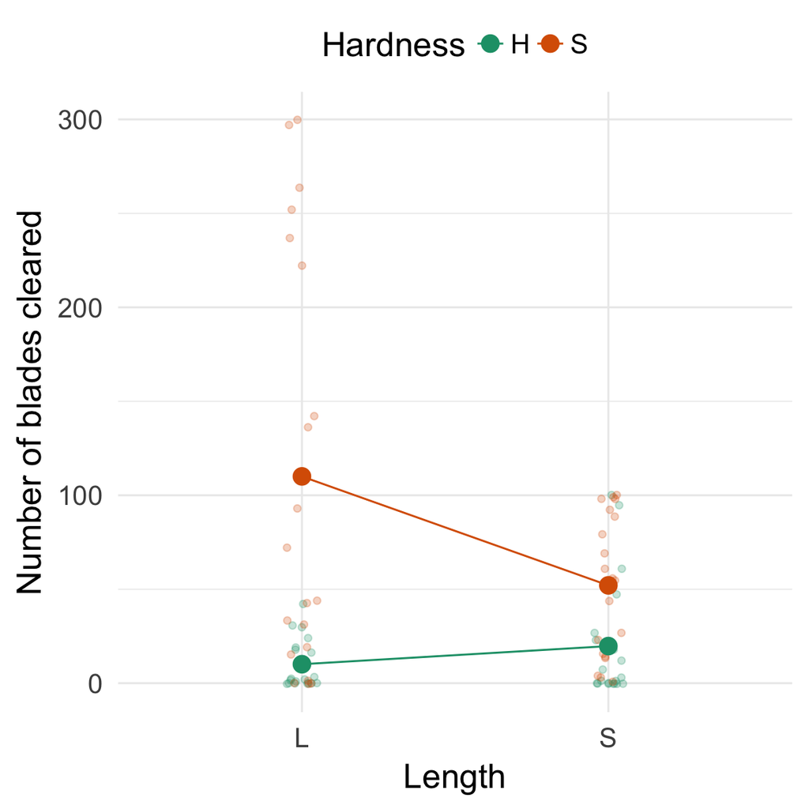

```r
ggplot(num2, aes(x = Length, y = Numbercleared, color = Hardness, group = Hardness)) +
  geom_jitter(alpha = 0.25, width = 0.05) +
  stat_summary(fun.y = mean, geom = "point", size = 4) +
  stat_summary(fun.y = mean, geom = "line") +
  ylab("Number of blades cleared") +
  scale_color_brewer("Hardness", palette = "Dark2") +
  theme_minimal(base_size = 18) +
  theme(legend.position = "top")
```

### 2.1.2 Model selection

Note: a first pass at the model showed that the residuals weren’t very clean. I used a square root transformation to correct some of it.

```r
m_full_num_2 <- lmer(sqrt(Numbercleared) ~ Length * Hardness + (1 | ColonyID), data = num2, REML = FALSE)
m_no_interaction_num_2 <- lmer(sqrt(Numbercleared) ~ Length + Hardness + (1 | ColonyID), data = num2, REML = FALSE)
anova(m_full_num_2, m_no_interaction_num_2)
```

```
## Data: num2
## Models:
## m_no_interaction_num_2: sqrt(Numbercleared) ~ Length + Hardness + (1 | ColonyID)
## m_full_num_2: sqrt(Numbercleared) ~ Length * Hardness + (1 | ColonyID)
##                        Df    AIC    BIC  logLik deviance  Chisq Chi Df
## m_no_interaction_num_2  5 437.82 449.73 -213.91   427.82
## m_full_num_2            6 435.38 449.67 -211.69   423.38 4.4458      1
##                        Pr(>Chisq)
## m_no_interaction_num_2
## m_full_num_2              0.03499 *
## ---
## Signif. codes:  0 '***' 0.001 '**' 0.01 '*' 0.05 '.' 0.1 ' ' 1
```

There is a statistical difference between the full model and the model without interaction.We’ll continue with the full model.

### 2.1.3 Model diagnostic

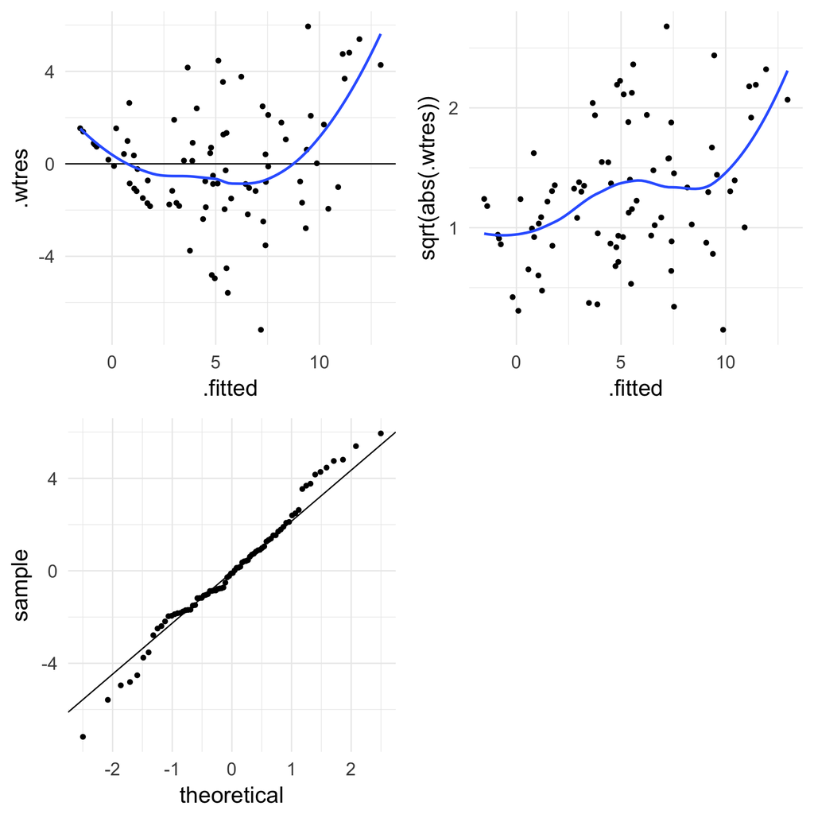

```r
diagnostic <- augment(m_full_num_2)

a <- ggplot(diagnostic, aes(x = .fitted, y = .wtres)) +
  geom_point() +
  geom_hline(yintercept = 0) +
  geom_smooth(se = FALSE) +
  theme_minimal(base_size = 18) +
  theme(legend.position = "top")

b <- ggplot(diagnostic, aes(x = .fitted, y = sqrt(abs(.wtres)))) +
  geom_point() +
  geom_smooth(se = FALSE) +
  theme_minimal(base_size = 18) +
  theme(legend.position = "top")

y <- quantile(diagnostic$.resid, c(0.25, 0.75))
x <- qnorm(c(0.25, 0.75))
slope <- diff(y) / diff(x)
int   <- y[1] - slope * x[1]
c <- ggplot(fortify(m_full_num_2), aes(sample = .resid)) +
  geom_qq() +
  geom_abline(intercept = int, slope = slope) +
  theme_minimal(base_size = 18) +
  theme(legend.position = "top")

cowplot::plot_grid(a, b, c)
```

Not perfect, but that’ll do.

### 2.1.4 Model evaluation

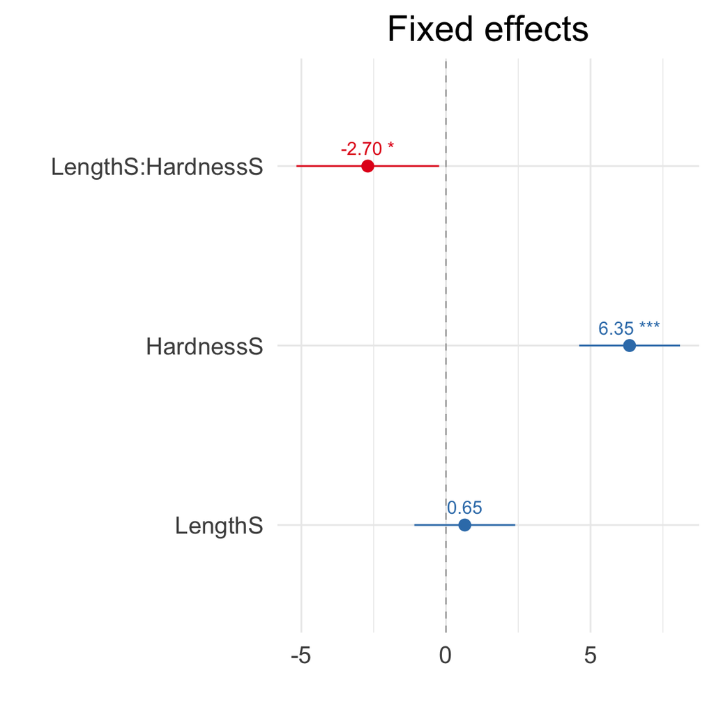

|  |  | B | CI | p |
| --- | --- | --- | --- | --- |
| Fixed Parts |  |  |  |  |
| (Intercept) |  | 2.27 | 0.57 – 3.98 | .011 |
| LengthS |  | 0.65 | -1.09 – 2.39 | .467 |
| HardnessS |  | 6.35 | 4.60 – 8.09 | <.001 |
| LengthS:HardnessS |  | -2.70 | -5.17 – -0.24 | .035 |
| Random Parts |  |  |  |  |
| σ<sup>2</sup> |  | 7.914 |  |  |
| τ<sub>00, ColonyID</sub> |  | 7.275 |  |  |
| N<sub>ColonyID</sub> |  | 20 |  |  |
| ICC<sub>ColonyID</sub> |  | 0.479 |  |  |
| Observations |  | 80 |  |  |
| R<sup>2</sup> / Ω<sub>0</sub><sup>2</sup> |  | .720 / .711 |  |  |

```r
sjp.lmer(m_full_num_2, type = "fe", prnt.plot = FALSE)$plot +
  theme_minimal(base_size = 18) +
  theme(plot.title = element_text(hjust = 0.5))
```

Back to top

## 2.2 Proportion of blades cleared

### 2.2.1 Graph

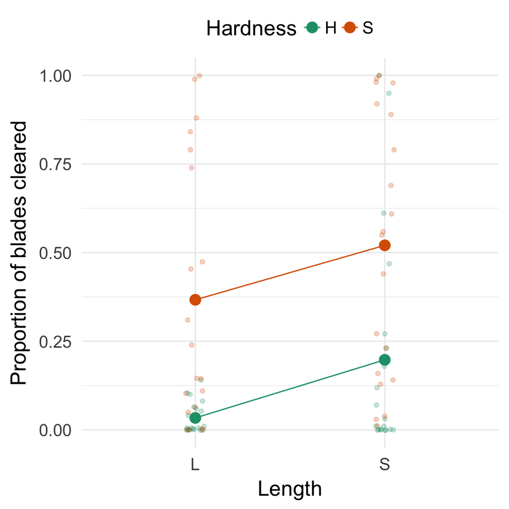

```r
ggplot(prop2, aes(x = Length, y = Propcleared, color = Hardness, group = Hardness)) +
  geom_jitter(alpha = 0.25, width = 0.05) +
  stat_summary(fun.y = mean, geom = "point", size = 4) +
  stat_summary(fun.y = mean, geom = "line") +
  ylab("Proportion of blades cleared") +
  scale_color_brewer("Hardness", palette = "Dark2") +
  theme_minimal(base_size = 18) +
  theme(legend.position = "top")
```

### 2.2.2 Model selection

Note: a first pass at the model showed that the residuals weren’t very clean. I used a square root transformation to correct some of it.

```r
m_full_prop_2 <- lmer(sqrt(Propcleared) ~ Length * Hardness + (1 | ColonyID), data = prop2, REML = FALSE)
m_no_interaction_prop_2 <- lmer(sqrt(Propcleared) ~ Length + Hardness + (1 | ColonyID), data = prop2, REML = FALSE)
anova(m_full_prop_2, m_no_interaction_prop_2)
```

```
## Data: prop2
## Models:
## m_no_interaction_prop_2: sqrt(Propcleared) ~ Length + Hardness + (1 | ColonyID)
## m_full_prop_2: sqrt(Propcleared) ~ Length * Hardness + (1 | ColonyID)
##                         Df    AIC    BIC  logLik deviance Chisq Chi Df
## m_no_interaction_prop_2  5 14.614 26.525 -2.3072   4.6145
## m_full_prop_2            6 16.614 30.906 -2.3070   4.6140 5e-04      1
##                         Pr(>Chisq)
## m_no_interaction_prop_2
## m_full_prop_2               0.9824
```

No statistical difference between the full model and the model without interaction. We’ll continue with the model without interaction.

### 2.2.3 Model diagnostic

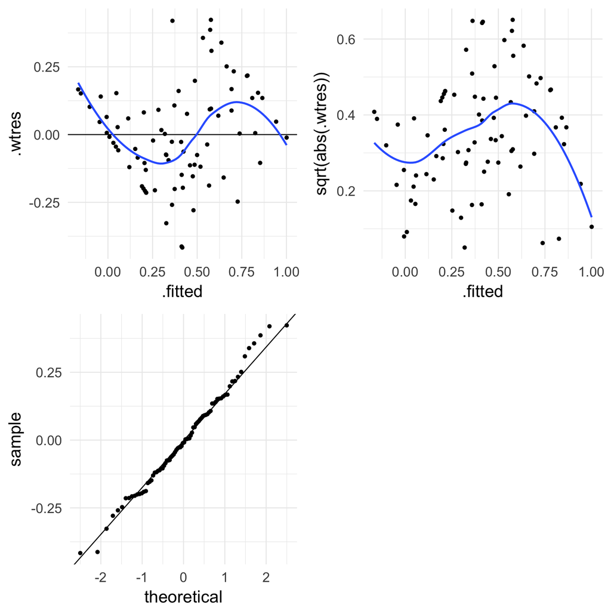

```r
diagnostic <- augment(m_no_interaction_prop_2)

a <- ggplot(diagnostic, aes(x = .fitted, y = .wtres)) +
  geom_point() +
  geom_hline(yintercept = 0) +
  geom_smooth(se = FALSE) +
  theme_minimal(base_size = 18) +
  theme(legend.position = "top")

b <- ggplot(diagnostic, aes(x = .fitted, y = sqrt(abs(.wtres)))) +
  geom_point() +
  geom_smooth(se = FALSE) +
  theme_minimal(base_size = 18) +
  theme(legend.position = "top")

y <- quantile(diagnostic$.resid, c(0.25, 0.75))
x <- qnorm(c(0.25, 0.75))
slope <- diff(y) / diff(x)
int   <- y[1] - slope * x[1]
c <- ggplot(fortify(m_no_interaction_prop_2), aes(sample = .resid)) +
  geom_qq() +
  geom_abline(intercept = int, slope = slope) +
  theme_minimal(base_size = 18) +
  theme(legend.position = "top")

cowplot::plot_grid(a, b, c)
```

Not perfect, but that’ll do.

### 2.2.4 Model evaluation

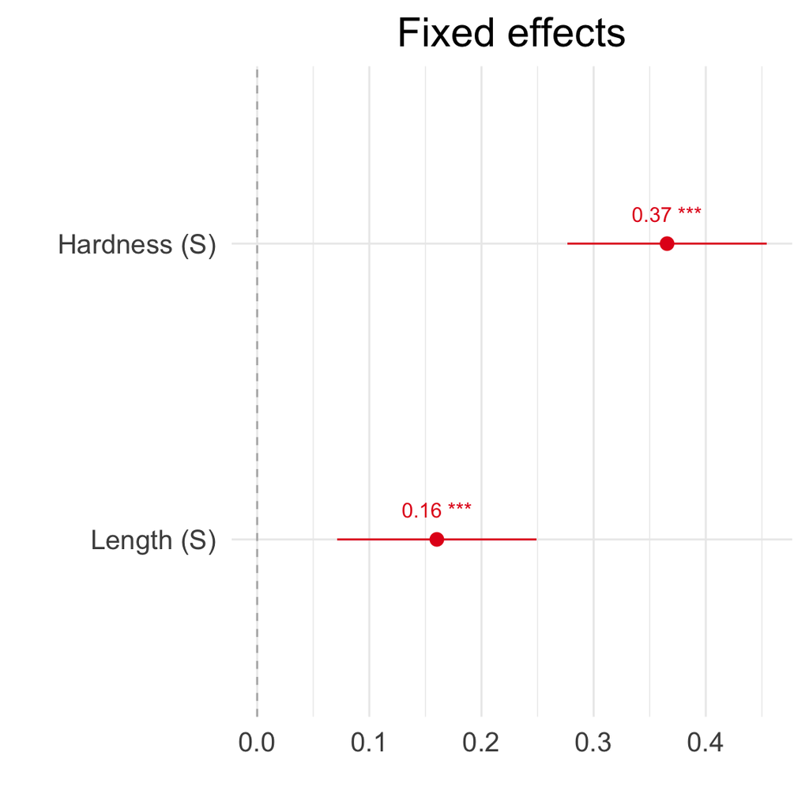

|  |  | B | CI | p |
| --- | --- | --- | --- | --- |
| Fixed Parts |  |  |  |  |
| (Intercept) |  | 0.13 | 0.01 – 0.25 | .033 |
| Length (S) |  | 0.16 | 0.07 – 0.25 | <.001 |
| Hardness (S) |  | 0.37 | 0.28 – 0.45 | <.001 |
| Random Parts |  |  |  |  |
| σ<sup>2</sup> |  | 0.041 |  |  |
| τ<sub>00, ColonyID</sub> |  | 0.043 |  |  |
| N<sub>ColonyID</sub> |  | 20 |  |  |
| ICC<sub>ColonyID</sub> |  | 0.511 |  |  |
| Observations |  | 80 |  |  |
| R<sup>2</sup> / Ω<sub>0</sub><sup>2</sup> |  | .743 / .735 |  |  |

```r
sjp.lmer(m_no_interaction_prop_2, type = "fe", prnt.plot = FALSE)$plot +
  theme_minimal(base_size = 18) +
  theme(plot.title = element_text(hjust = 0.5))
```

Back to top

# 3 Day 4

## 3.1 Number of blades cleared

### 3.1.1 Graph

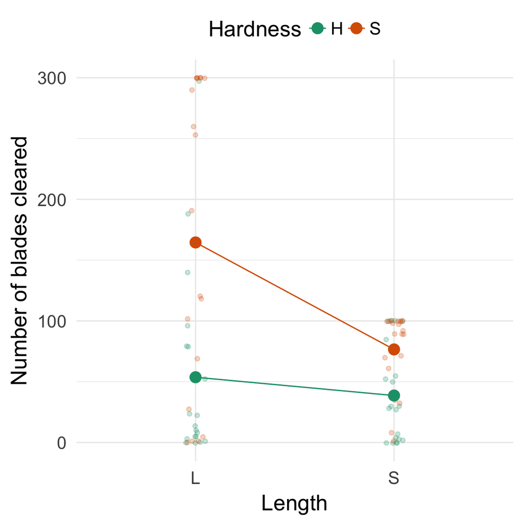

```r
ggplot(num4, aes(x = Length, y = Numbercleared, color = Hardness, group = Hardness)) +
  geom_jitter(alpha = 0.25, width = 0.05) +
  stat_summary(fun.y = mean, geom = "point", size = 4) +
  stat_summary(fun.y = mean, geom = "line") +
  ylab("Number of blades cleared") +
  scale_color_brewer("Hardness", palette = "Dark2") +
  theme_minimal(base_size = 18) +
  theme(legend.position = "top")
```

### 3.1.2 Model selection

Note: a first pass at the model showed that the residuals weren’t very clean. I used a square root transformation to correct some of it.

```r
m_full_num_4 <- lmer(sqrt(Numbercleared) ~ Length * Hardness + (1 | ColonyID), data = num4, REML = FALSE)
m_no_interaction_num_4 <- lmer(sqrt(Numbercleared) ~ Length + Hardness + (1 | ColonyID), data = num4, REML = FALSE)
anova(m_full_num_4, m_no_interaction_num_4)
```

```
## Data: num4
## Models:
## m_no_interaction_num_4: sqrt(Numbercleared) ~ Length + Hardness + (1 | ColonyID)
## m_full_num_4: sqrt(Numbercleared) ~ Length * Hardness + (1 | ColonyID)
##                        Df    AIC   BIC  logLik deviance  Chisq Chi Df
## m_no_interaction_num_4  5 462.69 474.6 -226.35   452.69
## m_full_num_4            6 462.51 476.8 -225.25   450.51 2.1874      1
##                        Pr(>Chisq)
## m_no_interaction_num_4
## m_full_num_4               0.1391
```

No statistical difference between the full model and the model without interaction. We’ll continue with the model without interaction.

### 3.1.3 Model diagnostic

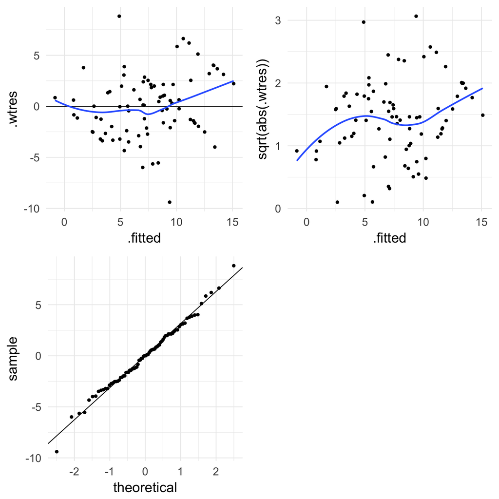

```r
diagnostic <- augment(m_no_interaction_num_4)

a <- ggplot(diagnostic, aes(x = .fitted, y = .wtres)) +
  geom_point() +
  geom_hline(yintercept = 0) +
  geom_smooth(se = FALSE) +
  theme_minimal(base_size = 18) +
  theme(legend.position = "top")

b <- ggplot(diagnostic, aes(x = .fitted, y = sqrt(abs(.wtres)))) +
  geom_point() +
  geom_smooth(se = FALSE) +
  theme_minimal(base_size = 18) +
  theme(legend.position = "top")

y <- quantile(diagnostic$.resid, c(0.25, 0.75))
x <- qnorm(c(0.25, 0.75))
slope <- diff(y) / diff(x)
int   <- y[1] - slope * x[1]
c <- ggplot(fortify(m_no_interaction_num_4), aes(sample = .resid)) +
  geom_qq() +
  geom_abline(intercept = int, slope = slope) +
  theme_minimal(base_size = 18) +
  theme(legend.position = "top")

cowplot::plot_grid(a, b, c)
```

Not perfect, but that’ll do.

### 3.1.4 Model evaluation

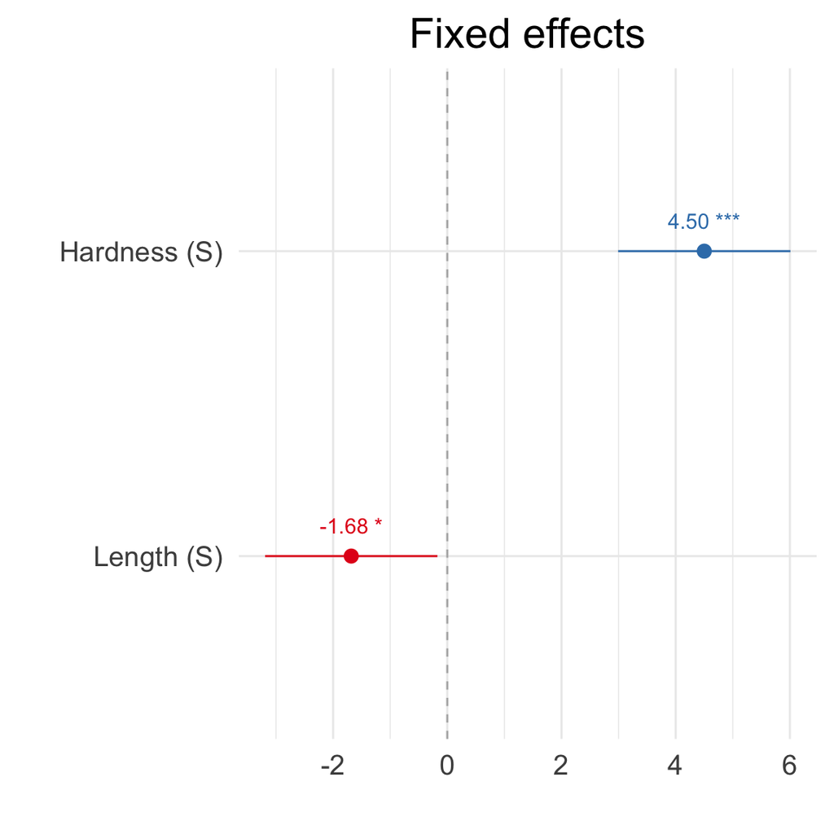

|  |  | B | CI | p |
| --- | --- | --- | --- | --- |
| Fixed Parts |  |  |  |  |
| (Intercept) |  | 6.13 | 4.27 – 7.98 | <.001 |
| Length (S) |  | -1.68 | -3.19 – -0.17 | .034 |
| Hardness (S) |  | 4.50 | 2.99 – 6.01 | <.001 |
| Random Parts |  |  |  |  |
| σ<sup>2</sup> |  | 11.854 |  |  |
| τ<sub>00, ColonyID</sub> |  | 8.964 |  |  |
| N<sub>ColonyID</sub> |  | 20 |  |  |
| ICC<sub>ColonyID</sub> |  | 0.431 |  |  |
| Observations |  | 80 |  |  |
| R<sup>2</sup> / Ω<sub>0</sub><sup>2</sup> |  | .653 / .638 |  |  |

```r
sjp.lmer(m_no_interaction_num_4, type = "fe", prnt.plot = FALSE)$plot +
  theme_minimal(base_size = 18) +
  theme(plot.title = element_text(hjust = 0.5))
```

Back to top

## 3.2 Proportion of blades cleared

### 3.2.1 Graph

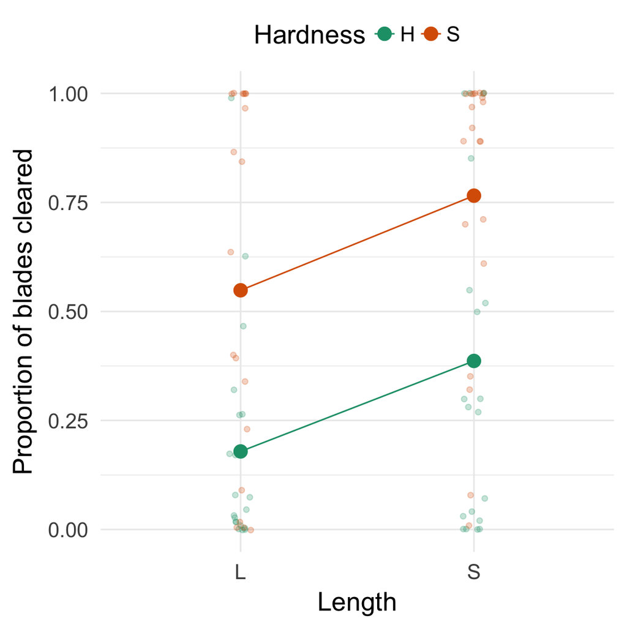

```r
ggplot(prop4, aes(x = Length, y = Propcleared, color = Hardness, group = Hardness)) +
  geom_jitter(alpha = 0.25, width = 0.05) +
  stat_summary(fun.y = mean, geom = "point", size = 4) +
  stat_summary(fun.y = mean, geom = "line") +
  ylab("Proportion of blades cleared") +
  scale_color_brewer("Hardness", palette = "Dark2") +
  theme_minimal(base_size = 18) +
  theme(legend.position = "top")
```

### 3.2.2 Model selection

Note: a first pass at the model showed that the residuals weren’t very clean. I used a square root transformation to correct some of it.

```r
m_full_prop_4 <- lmer(sqrt(Propcleared) ~ Length * Hardness + (1 | ColonyID), data = prop4, REML = FALSE)
m_no_interaction_prop_4 <- lmer(sqrt(Propcleared) ~ Length + Hardness + (1 | ColonyID), data = prop4, REML = FALSE)
anova(m_full_prop_4, m_no_interaction_prop_4)
```

```
## Data: prop4
## Models:
## m_no_interaction_prop_4: sqrt(Propcleared) ~ Length + Hardness + (1 | ColonyID)
## m_full_prop_4: sqrt(Propcleared) ~ Length * Hardness + (1 | ColonyID)
##                         Df    AIC    BIC  logLik deviance  Chisq Chi Df
## m_no_interaction_prop_4  5 31.657 43.568 -10.829   21.657
## m_full_prop_4            6 33.643 47.935 -10.822   21.643 0.0145      1
##                         Pr(>Chisq)
## m_no_interaction_prop_4
## m_full_prop_4               0.9042
```

No statistical difference between the full model and the model without interaction. We’ll continue with the model without interaction.

### 3.2.3 Model diagnostic

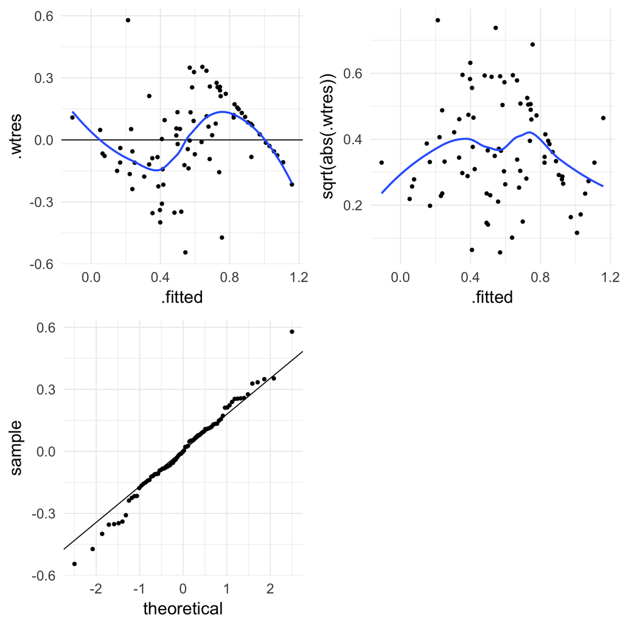

```r
diagnostic <- augment(m_no_interaction_prop_4)

a <- ggplot(diagnostic, aes(x = .fitted, y = .wtres)) +
  geom_point() +
  geom_hline(yintercept = 0) +
  geom_smooth(se = FALSE) +
  theme_minimal(base_size = 18) +
  theme(legend.position = "top")

b <- ggplot(diagnostic, aes(x = .fitted, y = sqrt(abs(.wtres)))) +
  geom_point() +
  geom_smooth(se = FALSE) +
  theme_minimal(base_size = 18) +
  theme(legend.position = "top")

y <- quantile(diagnostic$.resid, c(0.25, 0.75))
x <- qnorm(c(0.25, 0.75))
slope <- diff(y) / diff(x)
int   <- y[1] - slope * x[1]
c <- ggplot(fortify(m_no_interaction_prop_4), aes(sample = .resid)) +
  geom_qq() +
  geom_abline(intercept = int, slope = slope) +
  theme_minimal(base_size = 18) +
  theme(legend.position = "top")

cowplot::plot_grid(a, b, c)
```

Not perfect, but that’ll do.

### 3.2.4 Model evaluation

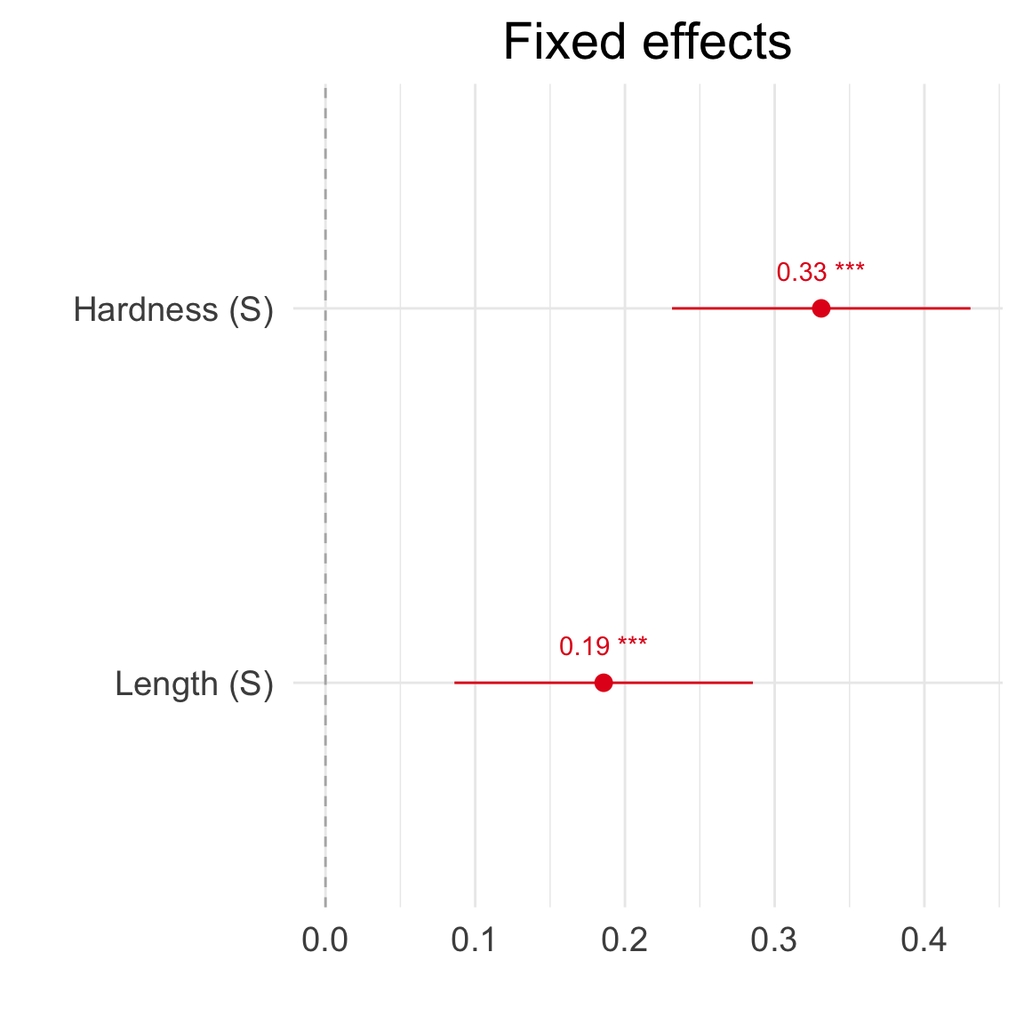

|  |  | B | CI | p |
| --- | --- | --- | --- | --- |
| Fixed Parts |  |  |  |  |
| (Intercept) |  | 0.32 | 0.19 – 0.45 | <.001 |
| Length (S) |  | 0.19 | 0.09 – 0.29 | <.001 |
| Hardness (S) |  | 0.33 | 0.23 – 0.43 | <.001 |
| Random Parts |  |  |  |  |
| σ<sup>2</sup> |  | 0.052 |  |  |
| τ<sub>00, ColonyID</sub> |  | 0.050 |  |  |
| N<sub>ColonyID</sub> |  | 20 |  |  |
| ICC<sub>ColonyID</sub> |  | 0.491 |  |  |
| Observations |  | 80 |  |  |
| R<sup>2</sup> / Ω<sub>0</sub><sup>2</sup> |  | .709 / .699 |  |  |

```r
sjp.lmer(m_no_interaction_prop_4, type = "fe", prnt.plot = FALSE)$plot +
  theme_minimal(base_size = 18) +
  theme(plot.title = element_text(hjust = 0.5))
```

Back to top